# Final_Activity_v3

Foster Thorburn

2022-12-11

```r
library(ggplot2)
library(dplyr)
library(RWDataPlyr)
library(readxl)
library(skimr)
library(forcats)
library(janitor)
library(stringr)
library(tidyr)
library(ggthemes)
library(tibble)
library(purrr)
library(ggplot2)
library(lubridate)
```

## Reading in Current Population Survey, December 2021: Food Security Supplement

```r
# Read in csv file
dec21pub <- read.csv("C:/Users/foste/Desktop/418 final project folder/dec21pub.csv")
```

Subsetting Food Supplement data set for variables

```r
data_dec21 <- select(dec21pub, GTCO, PRTAGE, PTDTRACE, PESEX,
                     PEMARITL, GESTFIPS, PEEDUCA,PEHSPNON, HRFS12M4, HRFS12M1, HRFS12MD)



#removing old F.S data sets
rm(dec21pub)
```

Creating unique County FIPS codes

```r
                            #state    #county
# Unique County FIPS code = [GESTFIPS][GTCO]

#SATE-CODE

#test var holds the value of the length of the state code
data_dec21 <- data_dec21 %>%
          mutate(test_var = nchar(as.character(factor(GESTFIPS))))

#code to add one zero to the front of the state code if there is only one value, if there is two adds nothing
data_dec21 <- data_dec21 %>%
  mutate(test_var2 = ifelse(data_dec21$test_var == 1, str_c("0",data_dec21$GESTFIPS,sep=""),data_dec21$GESTFIPS))


#COUNTY-CODE

#test_var_county holds the value of the length of the county code
data_dec21 <- data_dec21 %>%
          mutate(test_var_county = nchar(as.character(factor(GTCO))))


#code to add one zero to the front of the county code if there is less than or equal to two values
  data_dec21 <- data_dec21 %>%
  mutate(test_var2_county = ifelse(data_dec21$test_var_county <= 2, str_c("0",data_dec21$GTCO,sep=""),data_dec21$GTCO))

#Reruning the counter variable to find the length of the updated county code
data_dec21 <- data_dec21 %>%
          mutate(test_var_county = nchar(test_var2_county))

#Iterating a second time to add another zero if there's only two values, otherwise leave value be
data_dec21 <- data_dec21 %>%
  mutate(test_var2_county = ifelse(data_dec21$test_var_county <= 2, str_c("0",data_dec21$test_var2_county,sep=""),data_dec21$test_var2_county))

#UNIQUE-COUNTY CODE

data_dec21 <- data_dec21 %>%
          mutate(FIPS_code = str_c(test_var2,test_var2_county,sep=""))



#example function
#my_funct <- function() {
#  print("test")
#}
```

Re-coding Demographic Variables

```r
#Creating Date variable uisng libridate function make_date
data_dec21 <- data_dec21 %>%
  mutate(Date = make_date(year = 2021, month = 12)) #Condenses year and month to one variable


#Replacing -1 values with NA for entire data set
data_dec21 <- data_dec21 %>%
                  mutate(across(everything(), ~na_if(str_trim(.x), "-1")))
#Replacing -9 values with NA for entire data set
data_dec21 <- data_dec21 %>%
                  mutate(across(everything(), ~na_if(str_trim(.x), "-9")))
#Replacing -6 values with NA for entire data set
data_dec21 <- data_dec21 %>%
                  mutate(across(everything(), ~na_if(str_trim(.x), "-6")))

#Recoding Hispanic Variable - PEHSPNON
data_dec21 <- data_dec21 %>%
  mutate(Hispanic = factor(PEHSPNON) %>%
    fct_recode(
      "Hispanic" = "1",
      "Non-Hispanic" = "2"))



#Re-coding marital status variable
data_dec21 <- data_dec21 %>%
  mutate(Marital_status = factor(PEMARITL) %>%
    fct_recode(
      "MARRIED - SPOUSE PRESENT" = "1",
      "MARRIED - SPOUSE ABSENT" = "2",
      "WIDOWED" = "3",
      "DIVORCED" = "4",
      "SEPARATED" = "5",
      "NEVER MARRIED" = "6"))

#Re-coding highest complete degree variable
data_dec21 <- data_dec21 %>%
  mutate(High_Lvl_Degree = factor(PEEDUCA) %>%
    fct_recode(
      "Less than H.S or GED" = "31", #Grouping multiple Education Acheivements that are less than H.S or GED into one category
      "Less than H.S or GED" = "32",
      "Less than H.S or GED" = "33",
      "Less than H.S or GED" = "34",
      "Less than H.S or GED" = "35",
      "Less than H.S or GED" = "36",
      "Less than H.S or GED" = "37",
      "Less than H.S or GED" = "31",
      "Less than H.S or GED" = "38",
      "H.S or GED" = "39",
      "H.S or GED" = "40",
      "Associate's" = "41",
      "Associate's" = "42",
      "Bachelor's" = "43",
      "Master's" = "44",
      "Professional" = "45",
      "Doctorate" = "46"))


#Makes state variable GESTFIPS into character
data_dec21$GESTFIPS <- as.character(data_dec21$GESTFIPS)
#summary(data_dec21$GESTFIPS)

#Changing data set to make a new column called "Stabr" which is the state abbreviation
data_dec21 <- data_dec21 %>%
                   mutate(Stabr = factor(GESTFIPS) %>%
                     fct_recode(
           "AL" = "1",
           "AK" = "2",
           "AZ" = "4",
           "AR" = "5",
           "CA" = "6",
           "CO" = "8",
           "CT" = "9",
           "DE" = "10",
           "DC" = "11",
           "FL" = "12",
           "GA" = "13",
           "HI" = "15",
           "ID" = "16",
           "IL" = "17",
           "IN" = "18",
           "IA" = "19",
           "KS" = "20",
           "KY" = "21",
           "LA" = "22",
           "ME" = "23",
           "MD" = "24",
           "MA" = "25",
           "MI" = "26",
           "MN" = "27",
           "MS" = "28",
           "MO" = "29",
           "MT" = "30",
           "ME" = "31",
           "MV" = "32",
           "NH" = "33",
           "NJ" = "34",
           "NM" = "35",
           "NY" = "36",
           "NC" = "37",
           "ND" = "38",
           "OH" = "39",
           "OK" = "40",
           "OR" = "41",
           "PA" = "42",
           "RI" = "44",
           "SC" = "45",
           "SD" = "46",
           "TN" = "47",
           "TX" = "48",
           "UT" = "49",
           "VT" = "50",
           "VA" = "51",
           "WA" = "53",
           "WV" = "54",
           "WI" = "55",
           "WY" = "56"))



#Recoding Race Variable
data_dec21$PTDTRACE <- as.character(data_dec21$PTDTRACE)

data_dec21 <- data_dec21 %>%
  mutate(Race = factor(PTDTRACE) %>%
    fct_recode(
      "White Only" = "1",
      "Black Only" = "2",
      "American Indian, Alaskan Native Only" = "3",
      "Aisan Only" = "4",
      "Hawaiian/Pacific Islander Only" = "5",
      "White-Black" = "6",
      "White-AI" = "7",
      "White-Asian" = "8",
      "White-HP" = "9",
      "Black-AI" = "10",
      "Black-Asian" = "11",
      "Black-HP" = "12",
      "AI-Asian" = "13",
      "AI-HP" = "14",
      "Asian-HP" = "15",
      "3+ mixed-race" = "16", #Grouping multiple race categories into one category
      "3+ mixed-race" = "17",
      "3+ mixed-race" = "18",
      "3+ mixed-race" = "19",
      "3+ mixed-race" = "20",
      "3+ mixed-race" = "21",
      "3+ mixed-race" = "22",
      "3+ mixed-race" = "23",
      "3+ mixed-race" = "24",
      "3+ mixed-race" = "25",
      "3+ mixed-race" = "26"))



#Mutating to re-code Sex Variable
data_dec21 <- data_dec21 %>%
  mutate(Sex = factor(PESEX) %>%
    fct_recode(
      "Male" = "1",
      "Female" = "2"))

#Mutating to recode Age variable
 data_dec21 <- data_dec21 %>%
  mutate(Age = as.numeric(factor(PRTAGE)))
```

Re-coding Food Security Measures

```r
#Mutating to re code Main food insecurity measure variable
 data_dec21 <- data_dec21 %>%
  mutate(twelveM_Household_FI = factor(HRFS12M1) %>%
           fct_recode(
             "Food Secure High or Marginal Food Security" = "1",
             "Low Food Security" = "2",
             "Very Low Food Security" = "3"))

 #Mutating to recode food insecurity scale rasch variable
 data_dec21 <- data_dec21 %>%
  mutate(twelveM_Household_FI_rasch = factor(HRFS12M4))
 #Making the rasch variable numeric so it can be graphed

 data_dec21$twelveM_Household_FI_rasch <- as.numeric(as.character(data_dec21$twelveM_Household_FI_rasch))


 #Mutating to re code food insecurity variable which combines the main food insecurity measure into food insecure or not
 data_dec21 <- data_dec21 %>%
  mutate(FI_orNot = factor(HRFS12MD) %>%
           fct_recode(
             "High Food Security" = "1",
             "Food Insecure" = "2",
             "Food Insecure" = "3",
             "Food Insecure" = "4"))
```

Re-selecting Re-coded Variables for new data set

```r
data_dec21 <- select(data_dec21, Date, FIPS_code, Stabr, Age, Race, Sex, Hispanic,
                     Marital_status, High_Lvl_Degree, twelveM_Household_FI, twelveM_Household_FI_rasch, FI_orNot)
```

Data Exploration:

```r
summary(data_dec21$Age)
```

```
##    Min. 1st Qu.  Median    Mean 3rd Qu.    Max.    NA's
##    1.00   22.00   42.00   41.98   62.00   82.00   25464
```

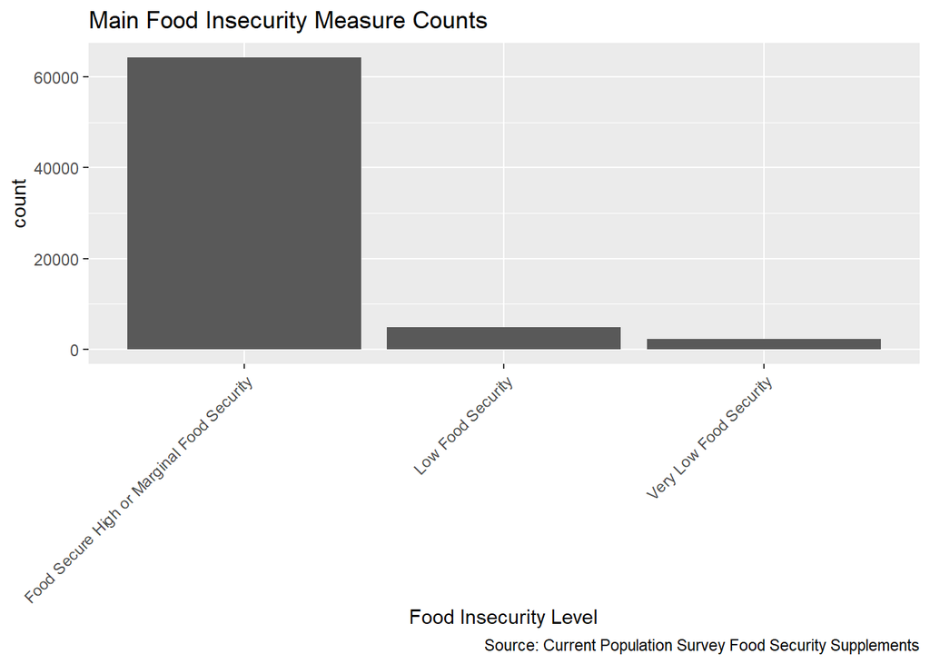

```r
#Food Insecurity Main measure
data_dec21 %>%  filter(!is.na(twelveM_Household_FI)) %>% ggplot(aes(x = twelveM_Household_FI)) +
  geom_bar() +
  theme(axis.text.x = element_text(angle=45, vjust=1, hjust=1)) + #45 degree angle labels
  labs(title = "Main Food Insecurity Measure Counts", x = "Food Insecurity Level", caption = "Source: Current Population Survey Food Security Supplements")
```

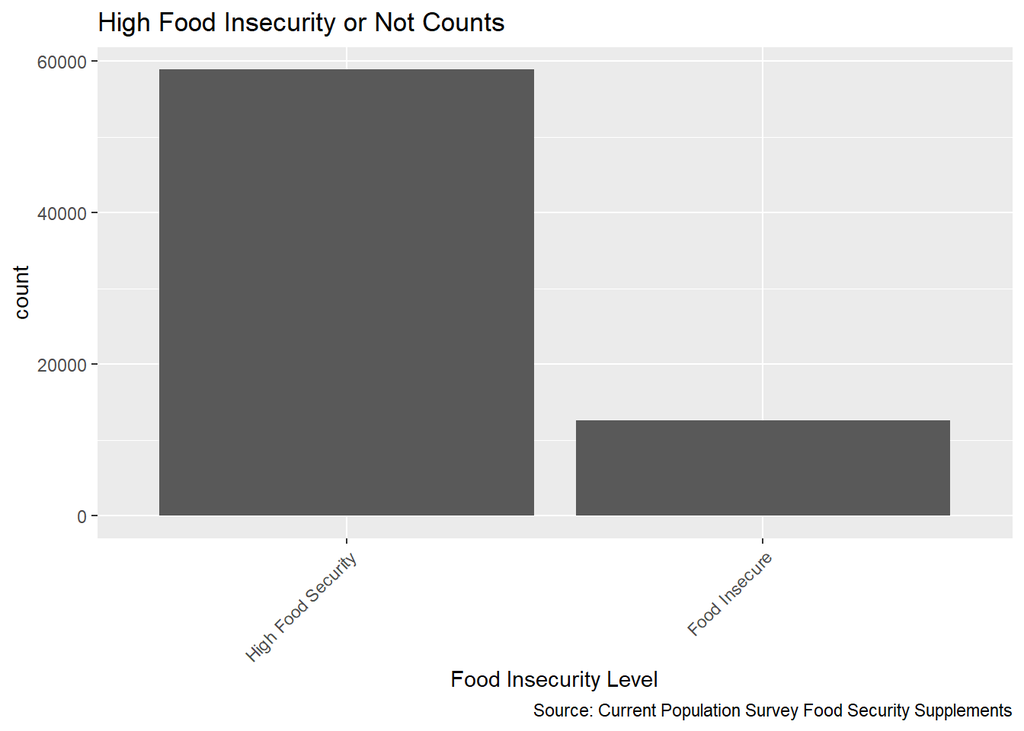

```r
#Food Insecurity
data_dec21 %>%  filter(!is.na(FI_orNot)) %>% ggplot(aes(x = FI_orNot)) +
  geom_bar() +
  theme(axis.text.x = element_text(angle=45, vjust=1, hjust=1)) + #45 degree angle labels
  labs(title = "High Food Insecurity or Not Counts", x = "Food Insecurity Level", caption = "Source: Current Population Survey Food Security Supplements")
```

In both categorizations of food insecurity, most people are food secure.

Based on the Counts of Race I have decided to make some of the values mixed race rather than their own category due to their relatively extremely low numbers:

Other Mixed Race: Black-Asian AI-HP Black-HP Asian-HP White-HP Black-AI AI-Asian 3+ mixed race

White-Black

White Asian

White-AI

White ONly

Asian Only

Black Only

American Indian, Alaskan Native Only

Hawaiian/Pacific Islander Only

Re-coding the Race variable:

```r
data_dec21 <- data_dec21 %>%
  mutate(Race = factor(Race) %>%
    fct_recode(
      "Other Mixed Race" = "Black-Asian", #Adding even more race cateogries to mixed race
      "Other Mixed Race" = "AI-HP",
      "Other Mixed Race" = "Black-HP",
      "Other Mixed Race" = "Asian-HP",
      "Other Mixed Race" = "White-HP",
      "Other Mixed Race" = "White-HP",
      "Other Mixed Race" = "Black-AI",
      "Other Mixed Race" = "AI-Asian",
      "Other Mixed Race" = "3+ mixed-race"))


data_dec21 %>% count(Race)
```

```
##                                    Race     n
## 1                            White Only 80955
## 2                      Other Mixed Race   557
## 3                            Black Only 11100
## 4  American Indian, Alaskan Native Only  1320
## 5                            Aisan Only  5768
## 6        Hawaiian/Pacific Islander Only   483
## 7                           White-Black   753
## 8                              White-AI   616
## 9                           White-Asian   473
## 10                                 <NA> 25464
```

## Data Dictionary

```r
skim(data_dec21)
```

Data summary

| Name | data_dec21 |
| --- | --- |
| Number of rows | 127489 |
| Number of columns | 12 |
| _______________________ |  |
| Column type frequency: |  |
| character | 2 |
| factor | 8 |
| numeric | 2 |
| ________________________ |  |
| Group variables | None |

**Variable type: character**

| skim_variable | n_missing | complete_rate | min | max | empty | n_unique | whitespace |
| --- | --- | --- | --- | --- | --- | --- | --- |
| Date | 0 | 1 | 10 | 10 | 0 | 1 | 0 |
| FIPS_code | 0 | 1 | 5 | 5 | 0 | 329 | 0 |

**Variable type: factor**

| skim_variable | n_missing | complete_rate | ordered | n_unique | top_counts |
| --- | --- | --- | --- | --- | --- |
| Stabr | 0 | 1.00 | FALSE | 50 | CA: 10189, TX: 7721, FL: 5833, NY: 4864 |
| Race | 25464 | 0.80 | FALSE | 9 | Whi: 80955, Bla: 11100, Ais: 5768, Ame: 1320 |
| Sex | 25464 | 0.80 | FALSE | 2 | Fem: 52162, Mal: 49863 |
| Hispanic | 25464 | 0.80 | FALSE | 2 | Non: 86707, His: 15318 |
| Marital_status | 43334 | 0.66 | FALSE | 6 | MAR: 41972, NEV: 25594, DIV: 8623, WID: 5490 |
| High_Lvl_Degree | 43334 | 0.66 | FALSE | 7 | H.S: 37447, Bac: 17656, Les: 10545, Ass: 8093 |
| twelveM_Household_FI | 56017 | 0.56 | FALSE | 3 | Foo: 64343, Low: 4820, Ver: 2309 |
| FI_orNot | 56017 | 0.56 | FALSE | 2 | Hig: 58901, Foo: 12571 |

**Variable type: numeric**

| skim_variable | n_missing | complete_rate | mean | sd | p0 | p25 | p50 | p75 | p100 | hist |
| --- | --- | --- | --- | --- | --- | --- | --- | --- | --- | --- |
| Age | 25464 | 0.8 | 41.98 | 23.46 | 1 | 22 | 42 | 62 | 82 | ▇▇▇▇▇ |
| twelveM_Household_FI_rasch | 114918 | 0.1 | 416.91 | 241.60 | 143 | 172 | 340 | 543 | 1303 | ▇▅▂▁▁ |

```r
glimpse(data_dec21)
```

```
## Rows: 127,489
## Columns: 12
## $ Date                       <chr> "2021-12-01", "2021-12-01", "2021-12-01", "…
## $ FIPS_code                  <chr> "01003", "01003", "01003", "01003", "01003"…
## $ Stabr                      <fct> AL, AL, AL, AL, AL, AL, AL, AL, AL, AL, AL,…
## $ Age                        <dbl> 56, 25, 22, 16, 38, 13, 23, 24, 47, 47, 69,…
## $ Race                       <fct> "White Only", "White Only", "White Only", "…
## $ Sex                        <fct> Male, Female, Male, Female, Male, Female, M…
## $ Hispanic                   <fct> Non-Hispanic, Non-Hispanic, Non-Hispanic, N…
## $ Marital_status             <fct> NEVER MARRIED, MARRIED - SPOUSE PRESENT, MA…
## $ High_Lvl_Degree            <fct> Bachelor's, Bachelor's, Bachelor's, H.S or …
## $ twelveM_Household_FI       <fct> Food Secure High or Marginal Food Security,…
## $ twelveM_Household_FI_rasch <dbl> NA, NA, NA, NA, NA, NA, NA, NA, NA, NA, NA,…
## $ FI_orNot                   <fct> High Food Security, NA, NA, NA, NA, NA, Hig…
```

```r
#Creating a table, assigning strings to go with each other to describe variables
dataDictionary <- tibble(Variable = colnames(data_dec21),
                         Description = c("Date: (Year-Month-Day)","Unique County Code", "Abreviated State Name", "Age (Years)", "Racial Identification", "Sex", "Hispanic Identification", "Marital Status","Highest Level Educational Degree Completed", "Household Food Security Scale, 12-Month Reference Period", "Food Security Rasch Scale Score, 12-Month Recall", "High Food Insecurity or Food Security (Marginal Food Security Counted as Food Insecure)"),
                         Type = map_chr(data_dec21, .f = function(x){typeof(x)[1]}),
                         Class = map_chr(data_dec21, .f = function(x){class(x)[1]}))
#printing table
knitr::kable(dataDictionary)
```

| Variable | Description | Type | Class |
| --- | --- | --- | --- |
| Date | Date: (Year-Month-Day) | character | character |
| FIPS_code | Unique County Code | character | character |
| Stabr | Abreviated State Name | integer | factor |
| Age | Age (Years) | double | numeric |
| Race | Racial Identification | integer | factor |
| Sex | Sex | integer | factor |
| Hispanic | Hispanic Identification | integer | factor |
| Marital_status | Marital Status | integer | factor |
| High_Lvl_Degree | Highest Level Educational Degree Completed | integer | factor |
| twelveM_Household_FI | Household Food Security Scale, 12-Month Reference Period | integer | factor |
| twelveM_Household_FI_rasch | Food Security Rasch Scale Score, 12-Month Recall | double | numeric |
| FI_orNot | High Food Insecurity or Food Security (Marginal Food Security Counted as Food Insecure) | integer | factor |

Patterns of NA:

There are no NA values for the geographic variables that are FIPS code and State (FIPS_code, Stabr).

Around 20% of the values of Age, Race, Sex, and Hispanic ID, are NA values.

Around 34% of the values of Marital Status and Highest Level Degree are NA’s

Around 44% of the values of the Categorical Food Insecurity measures are NA’s.

Each group of these variables that contain differing percentages of NA’s, are different kinds of variables with very consistent number of missing values for their category.

## Summary Statistics - Food Insecurity or Not

A breakdown by percentage of each group that is food insecure or not:

```r
#Highest Level Degree Completed
data_dec21 %>% filter(!is.na(FI_orNot)) %>%
tabyl(High_Lvl_Degree, FI_orNot) %>%
  adorn_percentages("row") %>% #gives percentages to the tables
  adorn_pct_formatting(digits = 1)
```

```
##       High_Lvl_Degree High Food Security Food Insecure
##  Less than H.S or GED              70.0%         30.0%
##            H.S or GED              79.2%         20.8%
##           Associate's              84.2%         15.8%
##            Bachelor's              92.1%          7.9%
##              Master's              94.7%          5.3%
##          Professional              96.5%          3.5%
##             Doctorate              97.1%          2.9%
##                  <NA>              77.3%         22.7%
```

```r
#Racial Identity
data_dec21 %>% filter(!is.na(FI_orNot)) %>%
tabyl(Race, FI_orNot) %>%
  adorn_percentages("row") %>%
  adorn_pct_formatting(digits = 1)
```

```
##                                  Race High Food Security Food Insecure
##                            White Only              84.7%         15.3%
##                      Other Mixed Race              69.6%         30.4%
##                            Black Only              67.9%         32.1%
##  American Indian, Alaskan Native Only              64.5%         35.5%
##                            Aisan Only              85.3%         14.7%
##        Hawaiian/Pacific Islander Only              69.9%         30.1%
##                           White-Black              69.1%         30.9%
##                              White-AI              68.4%         31.6%
##                           White-Asian              86.3%         13.7%
```

```r
#Hispanic Identity
data_dec21 %>% filter(!is.na(FI_orNot)) %>%
tabyl(Hispanic, FI_orNot) %>%
  adorn_percentages("row") %>%
  adorn_pct_formatting(digits = 1)
```

```
##      Hispanic High Food Security Food Insecure
##      Hispanic              70.9%         29.1%
##  Non-Hispanic              84.4%         15.6%
```

```r
#State abbreviation
data_dec21 %>% filter(!is.na(FI_orNot)) %>%
tabyl(Stabr, FI_orNot) %>%
  adorn_percentages("row") %>%
  adorn_pct_formatting(digits = 1)
```

```
##  Stabr High Food Security Food Insecure
##     AL              83.8%         16.2%
##     DE              81.4%         18.6%
##     DC              85.1%         14.9%
##     FL              82.6%         17.4%
##     GA              84.2%         15.8%
##     HI              83.7%         16.3%
##     ID              81.5%         18.5%
##     IL              84.4%         15.6%
##     IN              85.8%         14.2%
##     IA              82.0%         18.0%
##     AK              81.0%         19.0%
##     KS              83.9%         16.1%
##     KY              83.5%         16.5%
##     LA              77.3%         22.7%
##     ME              83.3%         16.7%
##     MD              85.5%         14.5%
##     MA              85.6%         14.4%
##     MI              81.7%         18.3%
##     MN              88.3%         11.7%
##     MS              74.6%         25.4%
##     MO              82.6%         17.4%
##     MT              82.9%         17.1%
##     MV              82.1%         17.9%
##     NH              91.0%          9.0%
##     NJ              83.4%         16.6%
##     NM              79.7%         20.3%
##     NY              82.6%         17.4%
##     NC              84.6%         15.4%
##     ND              88.9%         11.1%
##     OH              82.2%         17.8%
##     AZ              85.2%         14.8%
##     OK              72.3%         27.7%
##     OR              82.4%         17.6%
##     PA              85.5%         14.5%
##     RI              87.6%         12.4%
##     SC              79.8%         20.2%
##     SD              82.5%         17.5%
##     TN              84.8%         15.2%
##     TX              75.7%         24.3%
##     UT              82.3%         17.7%
##     AR              76.8%         23.2%
##     VT              87.7%         12.3%
##     VA              85.3%         14.7%
##     WA              86.5%         13.5%
##     WV              77.8%         22.2%
##     WI              85.1%         14.9%
##     WY              83.5%         16.5%
##     CA              80.8%         19.2%
##     CO              82.7%         17.3%
##     CT              83.0%         17.0%
```

```r
#Marital STatus
data_dec21 %>% filter(!is.na(FI_orNot)) %>%
tabyl(Marital_status, FI_orNot) %>%
  adorn_percentages("row") %>%
  adorn_pct_formatting(digits = 1)
```

```
##            Marital_status High Food Security Food Insecure
##  MARRIED - SPOUSE PRESENT              89.0%         11.0%
##   MARRIED - SPOUSE ABSENT              76.9%         23.1%
##                   WIDOWED              83.3%         16.7%
##                  DIVORCED              76.8%         23.2%
##                 SEPARATED              66.9%         33.1%
##             NEVER MARRIED              77.8%         22.2%
##                      <NA>              77.3%         22.7%
```

```r
#Highest Level Degree
data_dec21 %>% filter(!is.na(FI_orNot)) %>%
tabyl(High_Lvl_Degree, FI_orNot) %>%
  adorn_percentages("row") %>%
  adorn_pct_formatting(digits = 1)
```

```
##       High_Lvl_Degree High Food Security Food Insecure
##  Less than H.S or GED              70.0%         30.0%
##            H.S or GED              79.2%         20.8%
##           Associate's              84.2%         15.8%
##            Bachelor's              92.1%          7.9%
##              Master's              94.7%          5.3%
##          Professional              96.5%          3.5%
##             Doctorate              97.1%          2.9%
##                  <NA>              77.3%         22.7%
```

As educational degree completion rises, so does food security.

White Only, Asian only, and White-Asian identified groups are the most food secure populations out of other races. Every other race is twice as food insecure as a proportion of their population.

New Hampshire is a relatively food secure State.

Hispanics are about twice as food insecure as non-Hispanics as a proportion of their populations

The most food insecure marital status is separated spouses, the least is married with spouse present

Summary Statistics - Rasch Scores for characteristic Variables

```r
summary(data_dec21$twelveM_Household_FI_rasch)
```

```
##    Min. 1st Qu.  Median    Mean 3rd Qu.    Max.    NA's
##   143.0   172.0   340.0   416.9   543.0  1303.0  114918
```

```r
#Sex
data_dec21 %>% filter(!is.na(twelveM_Household_FI_rasch)) %>%
group_by(Sex) %>%
  summarise(
    n = n(),
    Median = median(twelveM_Household_FI_rasch),
    mean = mean(twelveM_Household_FI_rasch),
    sd = sd(twelveM_Household_FI_rasch),
    Min = min(twelveM_Household_FI_rasch),
    Max = max(twelveM_Household_FI_rasch)
  )
```

```
## # A tibble: 2 × 7
##   Sex        n Median  mean    sd   Min   Max
##   <fct>  <int>  <dbl> <dbl> <dbl> <dbl> <dbl>
## 1 Male    5958    340  415.  240.   143  1303
## 2 Female  6613    340  418.  243.   143  1303
```

```r
#Racial Identity
data_dec21 %>% filter(!is.na(twelveM_Household_FI_rasch)) %>%
group_by(Race) %>%
  summarise(
    n = n(),
    Median = median(twelveM_Household_FI_rasch),
    mean = mean(twelveM_Household_FI_rasch),
    sd = sd(twelveM_Household_FI_rasch),
    Min = min(twelveM_Household_FI_rasch),
    Max = max(twelveM_Household_FI_rasch)
  )
```

```
## # A tibble: 9 × 7
##   Race                                     n Median  mean    sd   Min   Max
##   <fct>                                <int>  <dbl> <dbl> <dbl> <dbl> <dbl>
## 1 White Only                            8763    340  413.  239.   143  1303
## 2 Other Mixed Race                       130    414  456.  239.   143   984
## 3 Black Only                            2300    414  435.  246.   143  1216
## 4 American Indian, Alaskan Native Only   338    414  458.  263.   143  1216
## 5 Aisan Only                             587    310  386.  252.   143  1303
## 6 Hawaiian/Pacific Islander Only          99    310  338.  190.   143  1015
## 7 White-Black                            164    340  395.  225.   143  1105
## 8 White-AI                               138    340  435.  272.   143  1105
## 9 White-Asian                             52    340  414.  265.   143  1105
```

```r
#State abbreviation
data_dec21 %>% filter(!is.na(twelveM_Household_FI_rasch)) %>%
group_by(Stabr) %>%
  summarise(
    n = n(),
    Median = median(twelveM_Household_FI_rasch),
    mean = mean(twelveM_Household_FI_rasch),
    sd = sd(twelveM_Household_FI_rasch),
    Min = min(twelveM_Household_FI_rasch),
    Max = max(twelveM_Household_FI_rasch)
  )
```

```
## # A tibble: 50 × 7
##    Stabr     n Median  mean    sd   Min   Max
##    <fct> <int>  <dbl> <dbl> <dbl> <dbl> <dbl>
##  1 AL      196    423  450.  230.   143  1015
##  2 DE      155    523  507.  236.   143  1105
##  3 DC      180    310  362.  237.   143   984
##  4 FL      476    340  408.  226.   143  1105
##  5 GA      225    340  398.  236.   143  1105
##  6 HI      183    340  385.  233.   143  1015
##  7 ID      241    340  399.  217.   143   898
##  8 IL      321    340  400.  253.   143  1216
##  9 IN      180    523  529.  286.   143  1105
## 10 IA      159    340  380.  215.   143  1105
## # … with 40 more rows
```

```r
#Hispanic Identity
data_dec21 %>% filter(!is.na(twelveM_Household_FI_rasch)) %>%
group_by(Hispanic) %>%
  summarise(
    n = n(),
    Median = median(twelveM_Household_FI_rasch),
    mean = mean(twelveM_Household_FI_rasch),
    sd = sd(twelveM_Household_FI_rasch),
    Min = min(twelveM_Household_FI_rasch),
    Max = max(twelveM_Household_FI_rasch)
  )
```

```
## # A tibble: 2 × 7
##   Hispanic         n Median  mean    sd   Min   Max
##   <fct>        <int>  <dbl> <dbl> <dbl> <dbl> <dbl>
## 1 Hispanic      3064    340  398.  232.   143  1303
## 2 Non-Hispanic  9507    414  423.  244.   143  1303
```

```r
#Marital Status
data_dec21 %>% filter(!is.na(twelveM_Household_FI_rasch)) %>%
group_by(Marital_status) %>%
  summarise(
    n = n(),
    Median = median(twelveM_Household_FI_rasch),
    mean = mean(twelveM_Household_FI_rasch),
    sd = sd(twelveM_Household_FI_rasch),
    Min = min(twelveM_Household_FI_rasch),
    Max = max(twelveM_Household_FI_rasch)
  )
```

```
## # A tibble: 7 × 7
##   Marital_status               n Median  mean    sd   Min   Max
##   <fct>                    <int>  <dbl> <dbl> <dbl> <dbl> <dbl>
## 1 MARRIED - SPOUSE PRESENT  3244    340  387.  225.   143  1303
## 2 MARRIED - SPOUSE ABSENT    168    423  436.  236.   143  1105
## 3 WIDOWED                    648    423  443.  250.   143  1303
## 4 DIVORCED                  1409    423  476.  262.   143  1216
## 5 SEPARATED                  309    423  470.  275.   143  1105
## 6 NEVER MARRIED             3938    414  435.  251.   143  1303
## 7 <NA>                      2855    340  384.  220.   143  1303
```

```r
#Highest Level Degree Completed
data_dec21 %>% filter(!is.na(twelveM_Household_FI_rasch)) %>%
group_by(High_Lvl_Degree) %>%
  summarise(
    n = n(),
    Median = median(twelveM_Household_FI_rasch),
    mean = mean(twelveM_Household_FI_rasch),
    sd = sd(twelveM_Household_FI_rasch),
    Min = min(twelveM_Household_FI_rasch),
    Max = max(twelveM_Household_FI_rasch)
  )
```

```
## # A tibble: 8 × 7
##   High_Lvl_Degree          n Median  mean    sd   Min   Max
##   <fct>                <int>  <dbl> <dbl> <dbl> <dbl> <dbl>
## 1 Less than H.S or GED  2122    414  432.  245.   143  1303
## 2 H.S or GED            5310    414  426.  246.   143  1303
## 3 Associate's            905    414  428.  250.   143  1303
## 4 Bachelor's            1011    340  417.  247.   143  1303
## 5 Master's               304    340  417.  251.   143  1113
## 6 Professional            30    310  412.  281.   143  1105
## 7 Doctorate               34    481  502.  282.   143  1105
## 8 <NA>                  2855    340  384.  220.   143  1303
```

```r
#This table breaks the Rasch score down by Race AND Sex
data_dec21 %>% filter(!is.na(twelveM_Household_FI_rasch)) %>%
group_by(Sex, Race) %>%
  summarise(
    n = n(),
    Median = median(twelveM_Household_FI_rasch),
    mean = mean(twelveM_Household_FI_rasch),
    sd = sd(twelveM_Household_FI_rasch),
    Min = min(twelveM_Household_FI_rasch),
    Max = max(twelveM_Household_FI_rasch)
  )
```

[output not shown]

```
## # A tibble: 18 × 8
## # Groups:   Sex [2]
##    Sex    Race                                  n Median  mean    sd   Min   Max
##    <fct>  <fct>                             <int>  <dbl> <dbl> <dbl> <dbl> <dbl>
##  1 Male   White Only                         4193   340   411.  237.   143  1303
##  2 Male   Other Mixed Race                     64   414   459.  228.   143   984
##  3 Male   Black Only                         1047   423   434.  245.   143  1216
##  4 Male   American Indian, Alaskan Native …   154   452   470.  252.   143  1105
##  5 Male   Aisan Only                          276   310   383.  247.   143  1303
##  6 Male   Hawaiian/Pacific Islander Only       46   340   334.  165.   143   661
##  7 Male   White-Black                          91   340   402.  235.   143  1105
##  8 Male   White-AI                             56   310   401.  272.   143  1105
##  9 Male   White-Asian                          31   481   473.  281.   143  1105
## 10 Female White Only                         4570   340   415.  240.   143  1303
## 11 Female Other Mixed Race                     66   418.  453.  251.   143   984
## 12 Female Black Only                         1253   414   436.  246.   143  1216
## 13 Female American Indian, Alaskan Native …   184   377   448.  272.   143  1216
## 14 Female Aisan Only                          311   310   388.  256.   143  1303
## 15 Female Hawaiian/Pacific Islander Only       53   256   342.  211.   143  1015
## 16 Female White-Black                          73   340   387.  214.   143  1105
## 17 Female White-AI                             82   414   458.  271.   143  1105
## 18 Female White-Asian                          21   340   328.  219.   143   898
```

Within the data documentation there is not an explanation given of the direction of the food insecurity scale. The means and medians differ but interpretation is difficult.

Male and Females have equal median values.

Hispanic has a lower median value than Non_Hispanic ID.

## rasch Scores

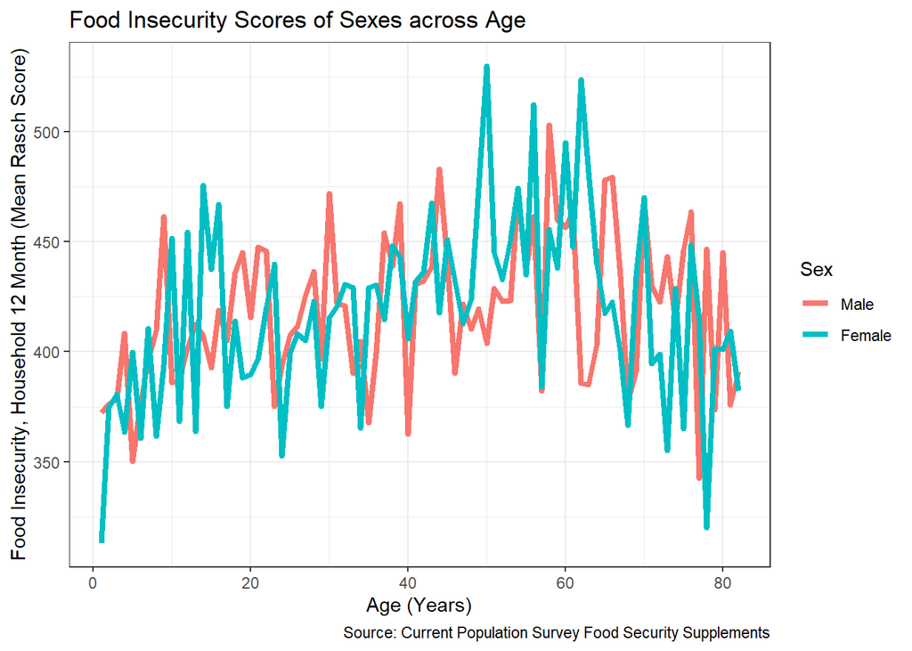

```r
#Graphing Food Insecurity Rasch scores by Age/Sex
data_dec21 %>% filter(!is.na(twelveM_Household_FI_rasch)) %>%
  ggplot(aes(x = Age, y = twelveM_Household_FI_rasch, color = Sex)) + #Color of plot divided by Sex
  stat_summary(aes(x = Age, y = twelveM_Household_FI_rasch, group = Sex), fun.y=mean, geom="line", size =1.5) + #Adds Sex line
  labs(y = "Food Insecurity, Household 12 Month (Mean Rasch Score)", title = "Food Insecurity Scores of Sexes across Age", caption = "Source: Current Population Survey Food Security Supplements",
       x = "Age (Years)") +
  theme_bw()
```

Food Insecurity is roughly parallel between Males and Females across all ages. The value of the Rasch score rises until mid 50’s and then falls until early 80’s for both. There are a couple places though that the scores diverge, such as at age ~50, and early 60’s.

Density Plot:

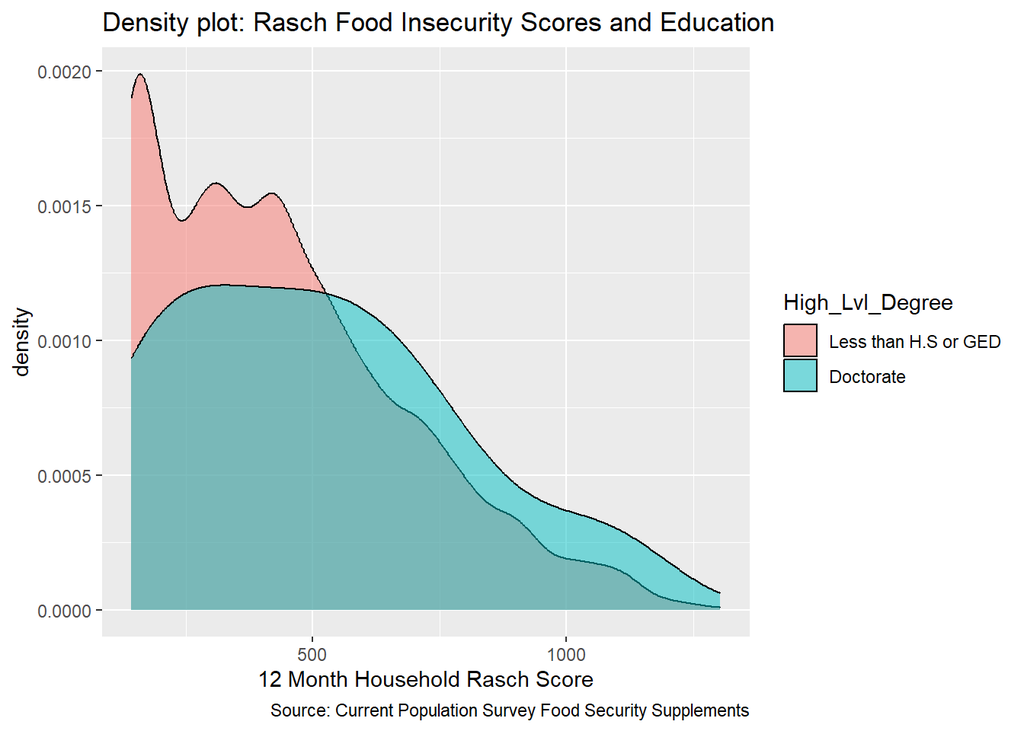

```r
#Making a new data frame with only associates and bachelor's degrees
dgr_df <- data_dec21 %>% filter(High_Lvl_Degree == "Doctorate" | High_Lvl_Degree == "Less than H.S or GED")

#Density Plot of Food Insecurity rasch scores
dgr_df %>% filter(!is.na(twelveM_Household_FI_rasch)) %>%
  ggplot(aes(x = twelveM_Household_FI_rasch, fill = High_Lvl_Degree)) +
  geom_density(alpha = .5) +
  labs(x ="12 Month Household Rasch Score",
       title = "Density plot: Rasch Food Insecurity Scores and Education",
       caption = "Source: Current Population Survey Food Security Supplements")
```

Interpretation is difficult given there’s not data documentation of the variable, but among degree attainments, these are the most different. This manifests in the density plot with less than High School or GED peaking for low Rasch score values, while Doctorate is much more spread and contains larger counts of high values. Based on intuition and this plot alone it would indicate that lower Rasch scores indicate food insecurity, and higher Rasch scores indicate Food Security.

## Merging Data set by County

Merged_DataSet is equivalent to data_dec21 except for an additional row that gives the percentage of the respective county that is in poverty

```r
#Read in xlsx file
poverty_data_large <- read_excel("C:/Users/foste/Desktop/418 final project folder/PovertyEstimates_new.xlsx")
poverty_data_county <- select(poverty_data_large,FIPS_code, PCTPOVALL_2020)
#rm(poverty_data_large)
```

Merging Data sets by inner join

```r
Merged_DataSet <-  data_dec21 %>% inner_join(poverty_data_county,by="FIPS_code")
rm(poverty_data_large)
```

## FI_orNot Variable

```r
#Creating d5 which holds the 10 counties with the highest percentage of food insecure
d4 <- Merged_DataSet %>% filter(!is.na(FIPS_code),!is.na(FI_orNot)) %>%
  group_by(Stabr,FIPS_code, FI_orNot) %>%
  summarise(count = n()) %>%
  mutate(perc_FI = count/sum(count))
```

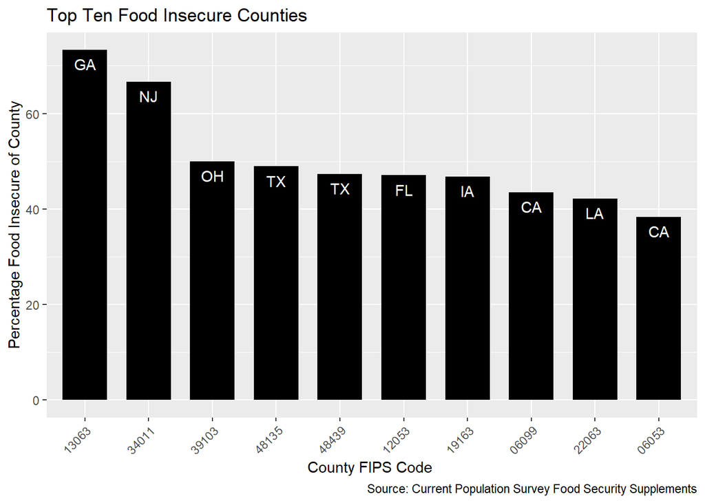

```r
d5 <- d4 %>% filter(FI_orNot == "Food Insecure") %>% arrange(desc(perc_FI))

d5 <- head(d5, 10)

#Top ten food insecure counties I have data on
d5 %>% filter(FI_orNot == "Food Insecure") %>%
  ggplot(aes(x = fct_reorder(FIPS_code, perc_FI, .desc = TRUE), y = perc_FI*100)) +
  geom_bar(stat = "identity", width = .7, fill = "black") +
  theme(axis.text.x = element_text(angle=45, vjust=1, hjust=1)) +
  labs(title = "Top Ten Food Insecure Counties",y = "Percentage Food Insecure of County",
       x = "County FIPS Code ",
       caption = "Source: Current Population Survey Food Security Supplements") +
  geom_text(aes(label = Stabr), nudge_y = -3, color = "white") #adds State abbreviation to plot
```

This bar graph shows the top 10 counties in the data for food insecurity, specifically using the FI_orNot variable, and looking at the percentage of that county in the data that is food insecure. One can look up more information on these counties using the FIPS code shown on the graph. These FIPS codes are standardized across the U.S. The abbreviation of the respective States was also added to the plot. This plot shows two counties from Texas in the top 10, as well as two counties from California.

RACE:

```r
# returns a data_frame that has the percentage of each race that is food insecure or not
d2 <- Merged_DataSet %>% filter(!is.na(Race),!is.na(FI_orNot)) %>%
  group_by(Race, FI_orNot) %>%
  summarise(count = n()) %>%
  mutate(perc_FIofRace = count/sum(count))
```

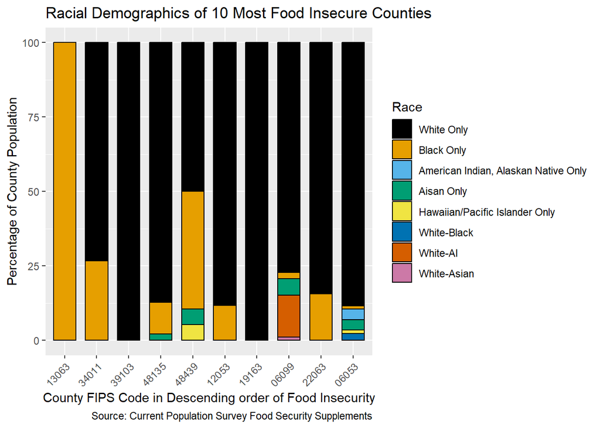

```r
#ggplot for percentage of each race that is food insecure
#d2 %>% filter(FI_orNot == "Food Insecure") %>%
#  ggplot(aes(x = fct_reorder(Race, perc_FIofRace, .desc = TRUE), y = perc_FIofRace*100)) +
#  geom_bar(stat = "identity", width = .7) +
#  theme(axis.text.x = element_text(angle=70, vjust=1, hjust=1)) +
#  labs(title = "Food Insecurity and Race",y = "Percentage Food Insecure ",
#      caption = "Source: Current Population Survey Food Security Supplements")


#now find the racial makeup of those counties, d6 holds the racial makeup for all counties with data
d6 <- Merged_DataSet %>% filter(!is.na(FIPS_code),!is.na(FI_orNot), !is.na(Race)) %>%
  group_by(Stabr,FIPS_code, Race) %>%
  summarise(count = n()) %>%
  mutate(perc_RaceCounty = count/sum(count))
#Merging data sets to create
Merged_FICounty_Race <- d5 %>% inner_join(d6,by="FIPS_code")


#Racial Makeup of 10 most food insecure counties by percentage
Merged_FICounty_Race %>%
  ggplot(aes(x = fct_reorder(FIPS_code, perc_FI, .desc = TRUE), y = perc_RaceCounty*100, fill = Race)) +
  geom_bar(stat = "identity", width = .7, color = "black") +
  labs(title = "Racial Demographics of 10 Most Food Insecure Counties",
       x = "County FIPS Code in Descending order of Food Insecurity",
       y = "Percentage of County Population",
       caption = "Source: Current Population Survey Food Security Supplements") +
  scale_fill_colorblind() +
  theme(axis.text.x = element_text(angle=45, vjust=1, hjust=1)) #adjusts the FIPS code angles
```

The top 10 food insecure counties in the data were taken then and put in the exact same order as previously listed, as in descending order from most food insecure as a percentage of the population to least. We now look at the data within these food insecure counties to look at racial demographics. In a couple of the counties there is a large Black population, which would be consistent with earlier data exploration findings of the association between food insecurity and race.

Looking at the data directly the confidence of these percentages being accurate to the real county demographics is very questionable. In 39103 there was only 7 people surveyed, all of which were white. A very small sample will not give us high confidence in neither the food insecurity proportion nor the racial demographic spread. Unique county codes had to be created from code and do not exist originally in the Current Population Food Security Supplements, and so I determine that the survery was most likley not intended for county level descriptions.

This racial makeup data does not take into account Hispanic status:

HISPANIC

```r
#creating a data frame that has the percentage hispanic in each in all counties with data
d7 <- Merged_DataSet %>% filter(!is.na(FIPS_code),!is.na(FI_orNot), !is.na(Hispanic)) %>%
  group_by(Stabr,FIPS_code, Hispanic) %>%
  summarise(count = n()) %>%
  mutate(perc_HispanicCounty = count/sum(count))
```

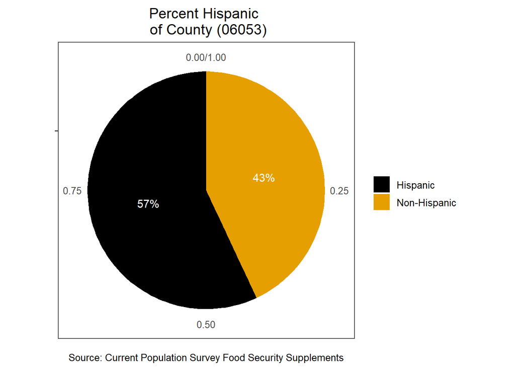

```r
d8 <- d7 %>% filter(Hispanic == "Hispanic")

#Merging to create a new data from top 10 most food insecure counties with
Merged_FICounty_Hispanic_Race <- d5 %>% inner_join(d8,by="FIPS_code")

#PIE chart for Hispanic ID proportion of county
d7 %>%  filter(FIPS_code == "06053") %>% ggplot(aes(x = "", y = perc_HispanicCounty, fill = Hispanic)) +
  geom_bar(stat = "identity", width = 1) +
  coord_polar("y", start=0) +
  geom_text(aes(label = paste0(round(perc_HispanicCounty*100, 1), "%")), position = position_stack(vjust=0.5), color = "white") +
  labs(x =NULL, y = NULL, fill = NULL,
    title = "Percent Hispanic \n of County (06053)",
    caption = "Source: Current Population Survey Food Security Supplements") +
  theme_few() +
  scale_fill_colorblind() +
  theme(plot.title = element_text(hjust = 0.5, vjust = 0.5), plot.caption = element_text(hjust = 0.5, vjust = 0.5))
```

Hispanic identification is not coded along with race, as the data documentation explains that any race can be Hispanic. But looking at the racial categories drawn in the data, it is missing some categories that live in the minds of the average American. Hispanic ID is associated with some of these categories.

Looking at the county 06053 from the top ten food insecure counties, which is Monterey County, CA, the population is 57% Hispanic. This county also had a low percentage of non-white residents compared to some other counties in the top ten.

RACE AND HISPANIC

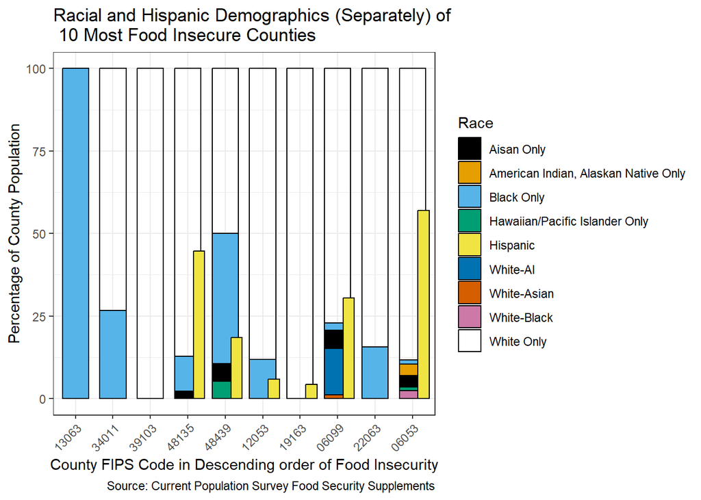

```r
#merging data to have both race and Hispanic percentages in a dataframe
merged_hisp_race_data <- Merged_FICounty_Race %>% full_join(Merged_FICounty_Hispanic_Race,by="FIPS_code")

#Racial and Hispanic Percentage of 10 most food insecure counties
merged_hisp_race_data %>%
  ggplot(aes(x = fct_reorder(FIPS_code, perc_FI.x, .desc = TRUE),y = perc_RaceCounty*100, fill = Race)) +
  geom_col(stat = "identity", width = .7, color = "black") +
  labs(title = "Racial and Hispanic Demographics (Separately) of\n 10 Most Food Insecure Counties",
       x = "County FIPS Code in Descending order of Food Insecurity",
       y = "Percentage of County Population",
       caption = "Source: Current Population Survey Food Security Supplements") +
  scale_fill_colorblind() +
  geom_col(aes(y = perc_HispanicCounty*100, fill = "Hispanic"), #Adding another column to the plot, Hispanic percent
         width = 0.3,
         position = position_nudge(x = 0.3), #Adjusting the position of that column
         color = "black") +
   theme_bw() +
  theme(axis.text.x = element_text(angle=45, vjust=1, hjust=1)) #adjusts the FIPS code angles
```

We now overlay the percentage of the county that is Hispanic onto the ggplot containing racial demographic proportions. The color scheme is reorganized to accomidate the color of the Hispanic bar. Percentage Hispanic is a separate variable to the percentage of each race in the “Race” variable. If this plot is not read correctly then one could have incorrect interpretations about what percentage of “White Only” persons are Hispanic vs. percentage of “Black Only.” The second bar indicating Hispanic ID is also not meant to be stacked on top of the other Race levels (this would indicate that only the white coded population is Hispanic which is not true for every county).

If more coding was done, the height of each Hispanic bar could be raised or lowered depending on the share of each coded race (for a specific county) that is Hispanic. Data is available in the CPS to do so.

In counties such as 48135 and 06053 there is a large percentage of Hispanic people, while county 39103 has a completely White and non-Hispanic survey sample. The survey sample is very small, but not far from the demographics listed on the county’s Wikipedia: https://en.wikipedia.org/wiki/Medina_County,_Ohio.

Based on the visuals of this plot, Hispanic identity most likely is a piece of the puzzle left out by CPS Racial Demographic descriptions of food insecurity in Counties. Those looking to demonstrate disparities caused by historical or current discrimination should take this into account.

## Pivoting Wider

```r
# returns a data_frame that has the percentage of each Sex that is food insecure or not
d3 <- Merged_DataSet %>% filter(!is.na(Sex),!is.na(FI_orNot)) %>%
  group_by(Sex, FI_orNot) %>%
  summarise(count = n()) %>%
  mutate(perc_FIofSex = count/sum(count))
```

[output not shown]

```r
#pivot the data frame into a wide format
d3_wider <- d3 %>%
  pivot_wider(
    names_from = FI_orNot,
    values_from = count
  )

glimpse(d3_wider)
```

```
## Rows: 4
## Columns: 4
## Groups: Sex [2]
## $ Sex                  <fct> Male, Male, Female, Female
## $ perc_FIofSex         <dbl> 0.8289700, 0.1710300, 0.8194945, 0.1805055
## $ `High Food Security` <int> 28878, NA, 30023, NA
## $ `Food Insecure`      <int> NA, 5958, NA, 6613
```